# STAT509 Homework10

RUI XIAO

2018/4/10

## Problem 1

### (a)

```r
library(fGarch)
X = read.csv("NYA-2015-2017.csv",header=TRUE)
log_return = diff(log(X$Adj.Close))
log_return.ts = ts(data=log_return, start=c(2015,1), frequency=252,names="logret")
NYA_garch = garchFit(~garch(1,1),data=log_return.ts,cond.dist = c("norm"),include.mean=TRUE,algorithm = c("nlminb"),hessian = c("ropt"))
```

[output not shown]

[output cut: 28 more lines]

[output not shown]

```r
summary(NYA_garch)
```

```
##
## Title:
##  GARCH Modelling
##
## Call:
##  garchFit(formula = ~garch(1, 1), data = log_return.ts, cond.dist = c("norm"),
##     include.mean = TRUE, algorithm = c("nlminb"), hessian = c("ropt"))
##
## Mean and Variance Equation:
##  data ~ garch(1, 1)
## <environment: 0x0000000019dae048>
##  [data = log_return.ts]
##
## Conditional Distribution:
##  norm
##
## Coefficient(s):
##         mu       omega      alpha1       beta1
## 4.2493e-04  2.9514e-06  1.7523e-01  7.8000e-01
##
## Std. Errors:
##  based on Hessian
##
## Error Analysis:
##         Estimate  Std. Error  t value Pr(>|t|)
## mu     4.249e-04   2.109e-04    2.015  0.04389 *
## omega  2.951e-06   9.672e-07    3.051  0.00228 **
## alpha1 1.752e-01   3.761e-02    4.659 3.18e-06 ***
## beta1  7.800e-01   4.316e-02   18.072  < 2e-16 ***
## ---
## Signif. codes:  0 '***' 0.001 '**' 0.01 '*' 0.05 '.' 0.1 ' ' 1
##
## Log Likelihood:
##  2683.547    normalized:  3.559081
##
## Description:
##  Tue Apr 10 23:48:14 2018 by user: Roxanne
##
##
## Standardised Residuals Tests:
##                                 Statistic p-Value
##  Jarque-Bera Test   R    Chi^2  241.8454  0
##  Shapiro-Wilk Test  R    W      0.9712717 5.183077e-11
##  Ljung-Box Test     R    Q(10)  8.056018  0.6233651
##  Ljung-Box Test     R    Q(15)  13.11419  0.593478
##  Ljung-Box Test     R    Q(20)  20.98898  0.3977813
##  Ljung-Box Test     R^2  Q(10)  6.130223  0.8042064
##  Ljung-Box Test     R^2  Q(15)  9.166547  0.8686494
##  Ljung-Box Test     R^2  Q(20)  9.892716  0.9700758
##  LM Arch Test       R    TR^2   6.75648   0.8732779
##
## Information Criterion Statistics:
##       AIC       BIC       SIC      HQIC
## -7.107552 -7.083014 -7.107608 -7.098099
```

```r
half_life = ceiling(1-log(2)/log(NYA_garch@fit$par[3]+NYA_garch@fit$par[4]))
```

According to the Error Analysis above, we would know that the standard errors of parameter estimates $\alpha_0$, $\alpha_1$ and $\beta_1$ are 9.672e-07,3.761e-02 and 4.316e-02. The half-life of the volatility is 17.

### (b)

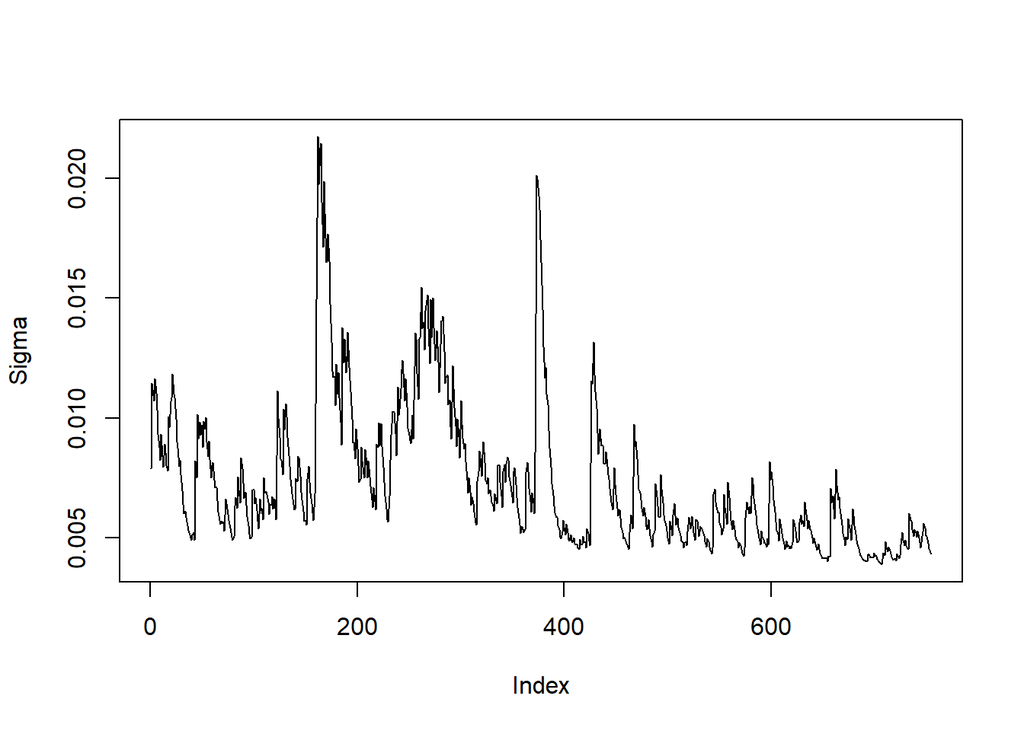

```r
plot(NYA_garch@sigma.t,type="l",ylab="Sigma")
```

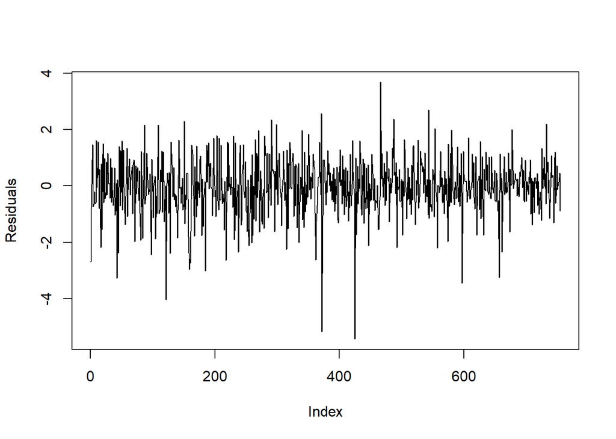

```r
plot(NYA_garch@residuals/NYA_garch@sigma.t,type="l",ylab="Residuals")
```

### (c)

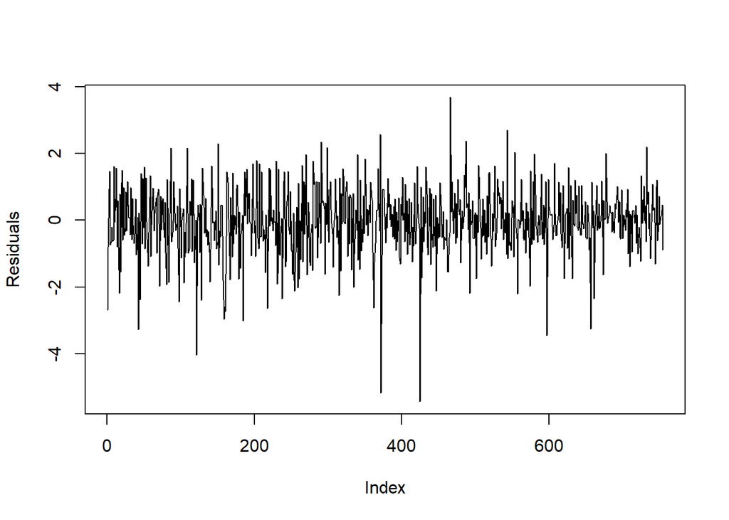

```r
plot(NYA_garch@residuals/NYA_garch@sigma.t,type="l",ylab="Residuals")
```

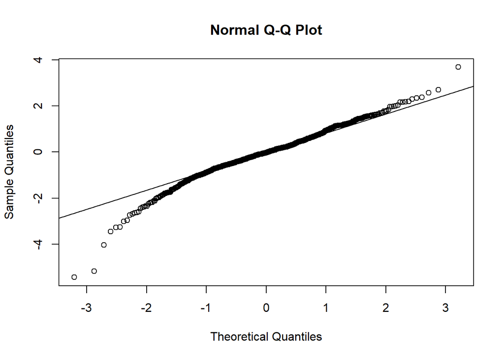

```r
qqnorm(NYA_garch@residuals/NYA_garch@sigma.t)
qqline(NYA_garch@residuals/NYA_garch@sigma.t)
```

```r
summary(NYA_garch)
```

```
##
## Title:
##  GARCH Modelling
##
## Call:
##  garchFit(formula = ~garch(1, 1), data = log_return.ts, cond.dist = c("norm"),
##     include.mean = TRUE, algorithm = c("nlminb"), hessian = c("ropt"))
##
## Mean and Variance Equation:
##  data ~ garch(1, 1)
## <environment: 0x0000000019dae048>
##  [data = log_return.ts]
##
## Conditional Distribution:
##  norm
##
## Coefficient(s):
##         mu       omega      alpha1       beta1
## 4.2493e-04  2.9514e-06  1.7523e-01  7.8000e-01
##
## Std. Errors:
##  based on Hessian
##
## Error Analysis:
##         Estimate  Std. Error  t value Pr(>|t|)
## mu     4.249e-04   2.109e-04    2.015  0.04389 *
## omega  2.951e-06   9.672e-07    3.051  0.00228 **
## alpha1 1.752e-01   3.761e-02    4.659 3.18e-06 ***
## beta1  7.800e-01   4.316e-02   18.072  < 2e-16 ***
## ---
## Signif. codes:  0 '***' 0.001 '**' 0.01 '*' 0.05 '.' 0.1 ' ' 1
##
## Log Likelihood:
##  2683.547    normalized:  3.559081
##
## Description:
##  Tue Apr 10 23:48:14 2018 by user: Roxanne
##
##
## Standardised Residuals Tests:
##                                 Statistic p-Value
##  Jarque-Bera Test   R    Chi^2  241.8454  0
##  Shapiro-Wilk Test  R    W      0.9712717 5.183077e-11
##  Ljung-Box Test     R    Q(10)  8.056018  0.6233651
##  Ljung-Box Test     R    Q(15)  13.11419  0.593478
##  Ljung-Box Test     R    Q(20)  20.98898  0.3977813
##  Ljung-Box Test     R^2  Q(10)  6.130223  0.8042064
##  Ljung-Box Test     R^2  Q(15)  9.166547  0.8686494
##  Ljung-Box Test     R^2  Q(20)  9.892716  0.9700758
##  LM Arch Test       R    TR^2   6.75648   0.8732779
##
## Information Criterion Statistics:
##       AIC       BIC       SIC      HQIC
## -7.107552 -7.083014 -7.107608 -7.098099
```

According to the results above, we would find that the residuals are not normal and heavy-tailed as it is shown in the QQ plot. The summary table of the model indicates that Ljung-Box Test are not significant, which means the residuals and volatility are not correlated.

### (d)

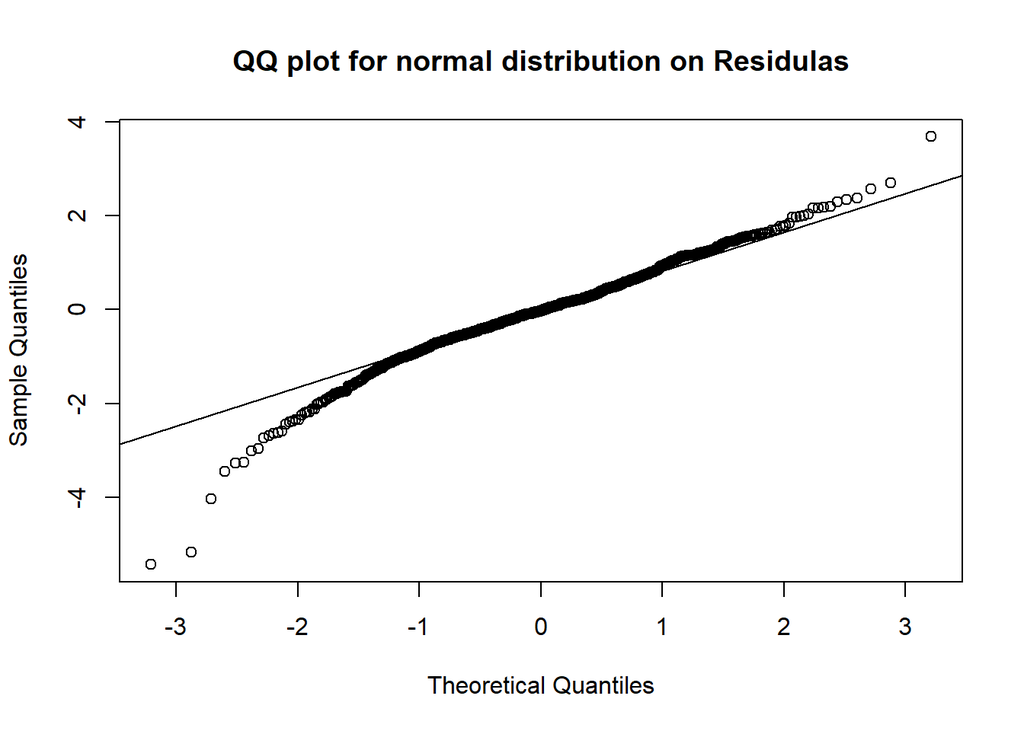

```r
library(mnormt)
library(MASS)
residual = NYA_garch@residuals/NYA_garch@sigma.t
df = seq(2,10,0.01)
n = length(df)
loglik_max = rep(0,n)
for (i in 1:n){
  fit = cov.trob(residual, nu=df[i])
  mu = fit$center
  sigma = fit$cov
  loglik_max[i] = sum(log(dmt(residual,mean=fit$center,S=fit$cov,df=df[i])))
}
nuest = df[which.max(loglik_max)]
N = length(residual)
quantv = (1/N)*seq(0.5,N-0.5,1)
qqnorm(NYA_garch@residuals/NYA_garch@sigma.t,main="QQ plot for normal distribution on Residulas")
qqline(NYA_garch@residuals/NYA_garch@sigma.t)
```

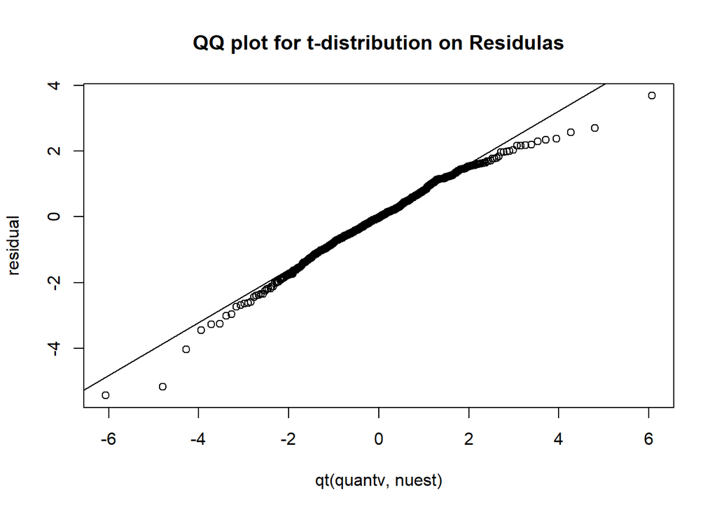

```r
qqplot(qt(quantv,nuest),residual, main="QQ plot for t-distribution on Residulas")
qqline(residual, distribution = function(p) qt(p,nuest), prob=c(0.1,0.9),col=1)
```

According to the results above, we would find the following,  
In QQ plot for normal distribution, the left tail is heavy-tailed, and the right tail is slightly heavy.  
In QQ plot for t-distribution, the left tail is slightly heavy, and the right tail becomes light-tailed.  
Therefore, we should use GARCH model with t conditional distribution.

## Problem 2

```r
pred = predict(NYA_garch,n.ahead=1)
rVaR_norm = 1-exp(qnorm(0.005,pred$meanForecast,pred$standardDeviation))
rVaR_t = 1-exp(pred$meanForecast+pred$standardDeviation*sqrt(nuest-2/nuest)*qt(0.005,nuest))
rVaR_norm
```

```
## [1] 0.01109385
```

```r
rVaR_t
```

```
## [1] 0.03799153
```

According to the results above, we would know that the relative VaR for the week following the last week of data for q = 0.005 is 0.01109385 if we assume the white noise process is normal. The relative VaR for the week following the last week of data for q = 0.005 is 0.03799153 if we assume white noise process follows the estimated t-distribution.

## Problem 3

### (a)

We would start with GARCH(1,1) with normal innovation.

```r
NYA_garch = garchFit(~garch(1,1),data=log_return.ts,cond.dist = c("norm"),include.mean = TRUE,algorithm = c("nlminb"),hessian = c("ropt"))
```

[output not shown]

[output cut: 28 more lines]

[output not shown]

```r
summary(NYA_garch)
```

```
##
## Title:
##  GARCH Modelling
##
## Call:
##  garchFit(formula = ~garch(1, 1), data = log_return.ts, cond.dist = c("norm"),
##     include.mean = TRUE, algorithm = c("nlminb"), hessian = c("ropt"))
##
## Mean and Variance Equation:
##  data ~ garch(1, 1)
## <environment: 0x00000000159344e8>
##  [data = log_return.ts]
##
## Conditional Distribution:
##  norm
##
## Coefficient(s):
##         mu       omega      alpha1       beta1
## 4.2493e-04  2.9514e-06  1.7523e-01  7.8000e-01
##
## Std. Errors:
##  based on Hessian
##
## Error Analysis:
##         Estimate  Std. Error  t value Pr(>|t|)
## mu     4.249e-04   2.109e-04    2.015  0.04389 *
## omega  2.951e-06   9.672e-07    3.051  0.00228 **
## alpha1 1.752e-01   3.761e-02    4.659 3.18e-06 ***
## beta1  7.800e-01   4.316e-02   18.072  < 2e-16 ***
## ---
## Signif. codes:  0 '***' 0.001 '**' 0.01 '*' 0.05 '.' 0.1 ' ' 1
##
## Log Likelihood:
##  2683.547    normalized:  3.559081
##
## Description:
##  Tue Apr 10 23:48:18 2018 by user: Roxanne
##
##
## Standardised Residuals Tests:
##                                 Statistic p-Value
##  Jarque-Bera Test   R    Chi^2  241.8454  0
##  Shapiro-Wilk Test  R    W      0.9712717 5.183077e-11
##  Ljung-Box Test     R    Q(10)  8.056018  0.6233651
##  Ljung-Box Test     R    Q(15)  13.11419  0.593478
##  Ljung-Box Test     R    Q(20)  20.98898  0.3977813
##  Ljung-Box Test     R^2  Q(10)  6.130223  0.8042064
##  Ljung-Box Test     R^2  Q(15)  9.166547  0.8686494
##  Ljung-Box Test     R^2  Q(20)  9.892716  0.9700758
##  LM Arch Test       R    TR^2   6.75648   0.8732779
##
## Information Criterion Statistics:
##       AIC       BIC       SIC      HQIC
## -7.107552 -7.083014 -7.107608 -7.098099
```

Then we would use AR(1) with GARCH(1,1) model with normal innovation.

```r
NYA_ar1garch=garchFit(~arma(1,0)+garch(1,1),data=log_return.ts,cond.dist=c("norm"),include.mean=TRUE,algorithm=c("nlminb"),hessian=c("ropt"))
```

[output not shown]

[output cut: 42 more lines]

[output not shown]

```r
summary(NYA_ar1garch)
```

```
##
## Title:
##  GARCH Modelling
##
## Call:
##  garchFit(formula = ~arma(1, 0) + garch(1, 1), data = log_return.ts,
##     cond.dist = c("norm"), include.mean = TRUE, algorithm = c("nlminb"),
##     hessian = c("ropt"))
##
## Mean and Variance Equation:
##  data ~ arma(1, 0) + garch(1, 1)
## <environment: 0x000000001b41b6e8>
##  [data = log_return.ts]
##
## Conditional Distribution:
##  norm
##
## Coefficient(s):
##          mu          ar1        omega       alpha1        beta1
##  4.7484e-04  -7.3785e-02   2.9095e-06   1.7843e-01   7.7845e-01
##
## Std. Errors:
##  based on Hessian
##
## Error Analysis:
##          Estimate  Std. Error  t value Pr(>|t|)
## mu      4.748e-04   2.116e-04    2.244  0.02485 *
## ar1    -7.378e-02   4.015e-02   -1.838  0.06613 .
## omega   2.909e-06   9.520e-07    3.056  0.00224 **
## alpha1  1.784e-01   3.847e-02    4.638 3.52e-06 ***
## beta1   7.784e-01   4.331e-02   17.974  < 2e-16 ***
## ---
## Signif. codes:  0 '***' 0.001 '**' 0.01 '*' 0.05 '.' 0.1 ' ' 1
##
## Log Likelihood:
##  2688.378    normalized:  3.565488
##
## Description:
##  Tue Apr 10 23:48:18 2018 by user: Roxanne
##
##
## Standardised Residuals Tests:
##                                 Statistic p-Value
##  Jarque-Bera Test   R    Chi^2  228.817   0
##  Shapiro-Wilk Test  R    W      0.9718387 7.146929e-11
##  Ljung-Box Test     R    Q(10)  7.924185  0.6362424
##  Ljung-Box Test     R    Q(15)  13.45908  0.5668843
##  Ljung-Box Test     R    Q(20)  23.39607  0.2697675
##  Ljung-Box Test     R^2  Q(10)  6.58365   0.764079
##  Ljung-Box Test     R^2  Q(15)  9.768791  0.834026
##  Ljung-Box Test     R^2  Q(20)  11.06016  0.9446475
##  LM Arch Test       R    TR^2   7.467708  0.8252231
##
## Information Criterion Statistics:
##       AIC       BIC       SIC      HQIC
## -7.117713 -7.087040 -7.117800 -7.105897
```

According to the result above, we would find that the coefficient of AR(1) is not significant, indicating that we would not add AR(1) with GARCH(1,1) if we use normal distribution for the innovation. Hence, we would choose GARCH(1,1) if we use normal distribution for the innovation.  
Next, we would use t-distribution for the innovation.

```r
NYA_garch_t = garchFit(~garch(1,1),data=log_return.ts,cond.dist = c("std"),include.mean = TRUE,algorithm = c("nlminb"),hessian = c("ropt"))
```

[output not shown]

[output cut: 42 more lines]

[output not shown]

```r
summary(NYA_garch_t)
```

```
##
## Title:
##  GARCH Modelling
##
## Call:
##  garchFit(formula = ~garch(1, 1), data = log_return.ts, cond.dist = c("std"),
##     include.mean = TRUE, algorithm = c("nlminb"), hessian = c("ropt"))
##
## Mean and Variance Equation:
##  data ~ garch(1, 1)
## <environment: 0x000000001b0963c0>
##  [data = log_return.ts]
##
## Conditional Distribution:
##  std
##
## Coefficient(s):
##         mu       omega      alpha1       beta1       shape
## 4.9988e-04  1.0278e-06  1.3949e-01  8.5385e-01  5.3279e+00
##
## Std. Errors:
##  based on Hessian
##
## Error Analysis:
##         Estimate  Std. Error  t value Pr(>|t|)
## mu     4.999e-04   1.908e-04    2.621 0.008780 **
## omega  1.028e-06   6.469e-07    1.589 0.112123
## alpha1 1.395e-01   4.092e-02    3.409 0.000653 ***
## beta1  8.539e-01   4.074e-02   20.961  < 2e-16 ***
## shape  5.328e+00   1.008e+00    5.286 1.25e-07 ***
## ---
## Signif. codes:  0 '***' 0.001 '**' 0.01 '*' 0.05 '.' 0.1 ' ' 1
##
## Log Likelihood:
##  2711.791    normalized:  3.596539
##
## Description:
##  Tue Apr 10 23:48:18 2018 by user: Roxanne
##
##
## Standardised Residuals Tests:
##                                 Statistic p-Value
##  Jarque-Bera Test   R    Chi^2  389.5632  0
##  Shapiro-Wilk Test  R    W      0.964627  1.576325e-12
##  Ljung-Box Test     R    Q(10)  7.727286  0.6554556
##  Ljung-Box Test     R    Q(15)  12.76554  0.6204017
##  Ljung-Box Test     R    Q(20)  19.23258  0.5067576
##  Ljung-Box Test     R^2  Q(10)  6.151665  0.802364
##  Ljung-Box Test     R^2  Q(15)  10.3678   0.7959886
##  Ljung-Box Test     R^2  Q(20)  12.63599  0.8924502
##  LM Arch Test       R    TR^2   6.992733  0.8580934
##
## Information Criterion Statistics:
##       AIC       BIC       SIC      HQIC
## -7.179816 -7.149144 -7.179903 -7.168000
```